# SEC Firms and their Relationship with High Net Worth Clients

### Group 3(Money Magnets): Dhanya Menon, Tim Jacobs, Jeff Leonard, Chloe McCabe, Abhineu Pradhan

Investment firms play an integral role in building their clients' wealth, guiding them in achieving long-term financial goals and navigating complex financial situations. The SEC identifies a high-net-worth individual as an “Accredited Investor”. Someone who has a net worth of at least 1 million or an income of at least 200,000 per year. They could also be someone who holds a financial professional license. For this project, we put ourselves in the shoes of an Investment Advisor planning to start a new business focused on High Net Worth Clients (HNWIs). We asked ourselves some key questions to guide our approach: Where should we set up our office? Where are high net worth clients geographically located? How should we structure our fees? And what level of assets under management should we aim for?

Our analysis looks at data available from US. Securities and Exchange Commission (SEC) to analyze how the distribution of high-net-worth individuals (HNWI) as well as the distribution of strategies used by investment advising firms vary widely based on firm size, location, and compensation structure.

Link: https://www.sec.gov/data-research/sec-markets-data/information-about-registered-investment-advisers-exempt-reporting-advisers

### Import modules, read in data

```python
import pandas as pd
import matplotlib.pyplot as plt
import matplotlib.ticker as mticker
import seaborn as sns

df_new = pd.read_csv("ia020325.csv",low_memory=False)
```

Using the Python libraries pandas, matplotlib, seaborn, and ipywidgets, we set out to analyze how firm size, location, and compensation structures influence their ability to attract HNW clients. We began by loading and preprocessing the dataset, ensuring all necessary columns were cleaned and converted to usable formats.

As an initial step in our analysis, we wanted to understand the geographic footprint of SEC registered firms. While our primary focus is on the firms operating within U.S, we observed there were firms headquartered outside the country. Before diving deeper into the trends and client distribution, we found it important to visualize how many firms fell into this catergory. In particular, we looked to identify what portion of the HNWI are associated with firms located outside U.S.

```python
#data prep
df14=df_new[["Primary Business Name", "Main Office State", "Main Office Country","Main Office Postal Code", "5D(b)(1)"]]
#Renaming Columns to be more understable, ex. 5(D)(b)(1) to read Number of clients
df14.columns=["Firm Name", "State Location","Country", "Office Zip Code", "Number of Clients"]
```

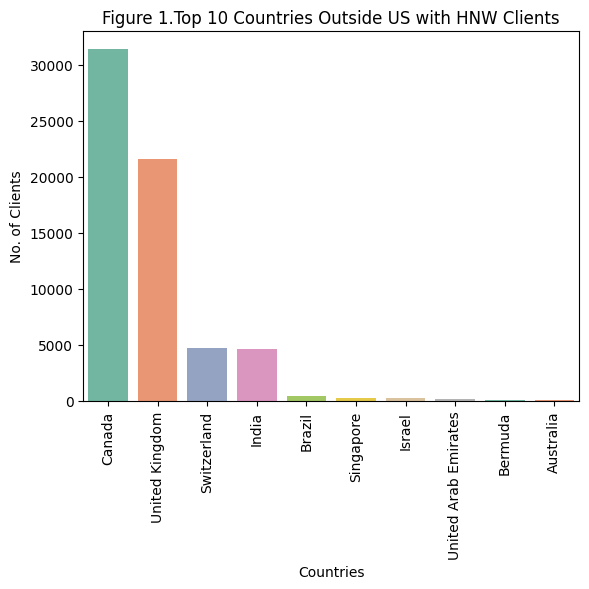

```python
#Filtering data to exclude firms not in U.S.
df16=df14[df14["Country"] != "United States"]. copy()
# Convert to numeric format
df16["Number of Clients"] = pd.to_numeric(df16["Number of Clients"], errors='coerce')
##Replace all null values in the column with "0"
df16["Number of Clients"]=df16["Number of Clients"].fillna(value=0)
#Need to groupby states and total HNW Client count
count=df16.groupby('Country')["Number of Clients"].sum()
#Sort in descending order
count= count.sort_values(ascending=False)
#sort top 10; resetting index column to regular column
top10= count.head(10).reset_index()
#create a barchart using the tutorial
sns.barplot(x='Country', y='Number of Clients', data=top10, palette="Set2")
plt.xlabel('Countries')
plt.ylabel('No. of Clients')
plt.title('Figure 1.Top 10 Countries Outside US with HNW Clients')
plt.xticks(rotation=90)
plt.show()
```

##### Canada and the United Kingdom lead by significant margin compared to other foreign countries, with Canada having over 31,000 HNW clients and UK more than 21,000 HNW clients

After identifying the presence of firms headquartered outside the United States and their share of HNW clients, we refined our analysis to focus on firms operating within the U.S.

```python
#Delete all non US rows.
df_new = df_new[df_new['Main Office Country'] == 'United States']
```

```python
df_new
```

|  | SEC Region | Organization CRD# | Additional CRD Number | Total number of additional CRD numbers | SEC# | Firm Type | Umbrella Registration | Total number of relying advisers | CIK# | Total number of CIK numbers | ... | Count of 11H(1)(b) disclosures | 11H(1)(c) | Count of 11H(1)(c) disclosures | 11H(2) | Count of 11H(2) disclosures | 12A | 12B(1) | 12B(2) | 12C(1) | 12C(2) |
| --- | --- | --- | --- | --- | --- | --- | --- | --- | --- | --- | --- | --- | --- | --- | --- | --- | --- | --- | --- | --- | --- |
| 0 | SFRO | 38 | NaN | NaN | 801-57838 | Registered | N | NaN | NaN | NaN | ... | 0 | N | 0 | N | 0 | NaN | NaN | NaN | NaN | NaN |
| 1 | NYRO | 70 | NaN | NaN | 801-56943 | Registered | N | NaN | 9319.0 | 1.0 | ... | 0 | N | 0 | N | 0 | NaN | NaN | NaN | NaN | NaN |
| 2 | NYRO | 79 | NaN | NaN | 801-3702 | Registered | N | NaN | 1362244.0 | 2.0 | ... | 0 | Y | 2 | N | 0 | NaN | NaN | NaN | NaN | NaN |
| 3 | SFRO | 199 | NaN | NaN | 801-45761 | Registered | N | NaN | 27182.0 | 1.0 | ... | 0 | N | 0 | N | 0 | NaN | NaN | NaN | NaN | NaN |
| 4 | NYRO | 231 | NaN | NaN | 801-54739 | Registered | N | NaN | 277871.0 | 1.0 | ... | 0 | Y | 3 | N | 0 | NaN | NaN | NaN | NaN | NaN |
| ... | ... | ... | ... | ... | ... | ... | ... | ... | ... | ... | ... | ... | ... | ... | ... | ... | ... | ... | ... | ... | ... |
| 15956 | NYRO | 157572 | NaN | NaN | 801-73627 | Registered | N | NaN | 1279030.0 | 1.0 | ... | 0 | N | 0 | N | 0 | NaN | NaN | NaN | NaN | NaN |
| 15957 | BRO | 104853 | NaN | NaN | 801-43127 | Registered | N | NaN | NaN | NaN | ... | 0 | N | 0 | N | 0 | NaN | NaN | NaN | NaN | NaN |
| 15959 | NYRO | 322260 | NaN | NaN | 801-126110 | Registered | N | NaN | NaN | NaN | ... | 0 | N | 0 | N | 0 | NaN | NaN | NaN | NaN | NaN |
| 15961 | NYRO | 163597 | NaN | NaN | 801-77719 | Registered | N | NaN | 1566691.0 | 1.0 | ... | 0 | N | 0 | N | 0 | NaN | NaN | NaN | NaN | NaN |
| 15962 | LARO | 328574 | NaN | NaN | 801-129101 | Registered | N | NaN | NaN | NaN | ... | 0 | N | 0 | N | 0 | NaN | NaN | NaN | NaN | NaN |

13969 rows × 461 columns

#### How many office locations in each state are serving HNW clients? How many HNW clients does each state have?

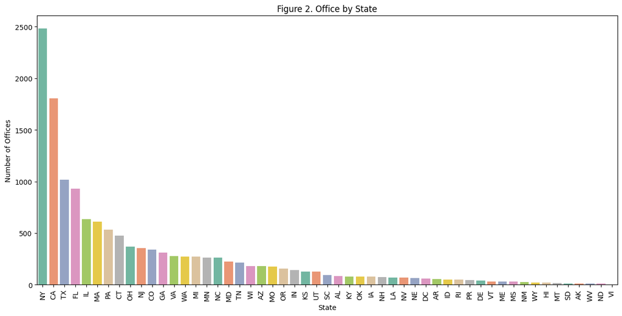

```python
df_new["temp1"] =1
#Need to groupby states and number of offices count; resetting index column to regular column
count = df_new.groupby("Main Office State")["temp1"].sum().reset_index()
#Sort in descending order
count= count.sort_values(by="temp1", ascending=False)
plt.figure(figsize=(15,7))
#create a bar chart
sns.barplot(x='Main Office State', y='temp1', data=count, palette="Set2")
plt.xlabel('State')
plt.ylabel('Number of Offices')
plt.title('Figure 2. Office by State')
plt.xticks(rotation=90)
plt.show()
```

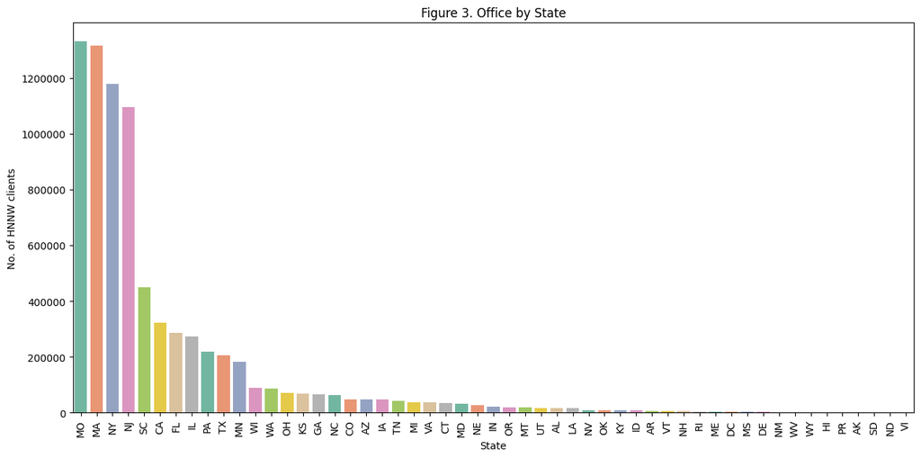

```python
##Replace all null values in the column with "0"
df_new["5D(b)(1)"]=df_new["5D(b)(1)"].fillna(value=0)
#Get the numbers in the column as an integer value
df_new["HNWC"]=df_new["5D(b)(1)"].apply(lambda x: int(x))
#Need to groupby states and total HNW Client count; resetting index column to regular column
count=df_new.groupby('Main Office State')["5D(b)(1)"].sum().reset_index()
#Sort in descending order
count= count.sort_values(by= "5D(b)(1)", ascending=False)
plt.figure(figsize=(15,7))
#create a bar chart
sns.barplot(x='Main Office State', y='5D(b)(1)', data=count, palette="Set2")
#Using plain formatting vs.scientific notation
plt.ticklabel_format(style='plain', axis='y')
plt.xlabel('State')
plt.ylabel('No. of HNNW clients')
plt.title('Figure 3. Office by State')
plt.xticks(rotation=90)
plt.show()
```

##### The results of this graph were very interesting to us. While New York has the highest number of firm offices, the above chart showing high net worth clients by state tells a different story. States like Missouri (MO) and Massachusetts (MA) actually serve the largest number of HNW clients. This suggests that a large physical office presence doesn’t always translate to a larger client base. The graph highlights certain states that have fewer firms but are highly specialized in wealth management. Missouri is home to some major brokerage firms (Edward Jones, and Wells Fargo Advisors to name a few) and clearing firms, while Massachusetts has a strong financial services hub in Boston. These firms may be serving clients nationwide, suggesting that specialized services might outweigh geographic footprint.

#### What factors define an effective HNW-focused firm?

From this column we are able to identify firms that priortize HNW clients in their business model and determine specific percentage groups to use for analysis later.

```python
#new column to count
df_new["temp1"] =1

# Remove hidden characters
df_new['5D(b)(3)'] = df_new['5D(b)(3)'].astype(str).str.strip()
df_new['5F(2)(c)'] = df_new['5F(2)(c)'].astype(str).str.strip()

# Remove non numeric stuff.
df_new['5D(b)(3)'] = df_new['5D(b)(3)'].str.replace(r'[^\d.]', '', regex=True)
df_new['5F(2)(c)'] = df_new['5F(2)(c)'].str.replace(r'[^\d.]', '', regex=True)

# Convert to numeric format
df_new['5D(b)(3)'] = pd.to_numeric(df_new['5D(b)(3)'], errors='coerce')
df_new['5F(2)(c)'] = pd.to_numeric(df_new['5F(2)(c)'], errors='coerce')
df_new[['5D(b)(3)', '5F(2)(c)']]

# Create new column for percentage of high net worth clients
df_new['High Net Worth Clients %'] = (df_new['5D(b)(3)'] / df_new['5F(2)(c)']) * 100

#Round to two decimals
df_new['High Net Worth Clients %'] = df_new['High Net Worth Clients %'].round(2)

#Change null values to 0%
df_new = df_new.fillna(value={"High Net Worth Clients %": 0})

#clean data
df_new[['High Net Worth Clients %']]

#import ipywidgets
from ipywidgets import widgets, interactive, Layout

#Create radio buttons to allow user to select the percentage threshold to display
w = widgets.RadioButtons(
    options=['All','25%', '50%', '75%', '99%'],
    value = "All",
    description='Percent of High Net Worth Clients',
    disabled=False
)

def view(percent):

    #Filter by user defined threshold
    if percent == "All":
        df_tmp = df_new[df_new['High Net Worth Clients %'] >= 0]
    if percent == "25%":
        df_tmp = df_new[df_new['High Net Worth Clients %'] >= 25]
    if percent == "50%":
        df_tmp = df_new[df_new['High Net Worth Clients %'] >= 50]
    if percent == "75%":
        df_tmp = df_new[df_new['High Net Worth Clients %'] >= 75]
    if percent == "99%":
        df_tmp = df_new[df_new['High Net Worth Clients %'] >= 99]


    #group by state and count
    count = df_tmp.groupby("Main Office State").temp1.sum()
    count= count.sort_values(ascending=False)

    #plot bar graph of counted data
    count.plot(kind="bar", title="Figure 4. Offices By State with High Net Worth Clients % greater than selected", grid=True, figsize=(15,5))


#create and display interactive chart
i = interactive(view, percent=w)
display(i)
```

```
interactive(children=(RadioButtons(description='Percent of High Net Worth Clients', options=('All', '25%', '50…
```

##### The above graph allows us to explore how the firms most committed to serving wealthy clients are concentrated. The graph helps in gaining clearer understanding of geographic specialization. When no filter is applied NY and CA lead with the highest number firms with HNW Clients, however, as users increase the threshold to ex. 50%, the distribution shift to show states with fewer but more specialized firms.

Next, we looked at RAUM (Regulatory Asset Under Management), which reflects the total dollar value of the client's wealth that the firm is entrusted to manage.

```python
#column 5F(2)(c) shows total RAUM
#rename column for clarity and grouping
df_new= df_new.rename(columns={"5F(2)(c)" : "totalraum"})

#remove commas from monetary values and convert data type from object to int for analysis
df_new['totalraum'] = df_new['totalraum'].replace(',', '').astype(int)

#get the sum of the total Regulated Assets Under Management for each state
raum = df_new.groupby("Main Office State").totalraum.sum()
#sort by descending values
raum = raum.sort_values(ascending = False)
```

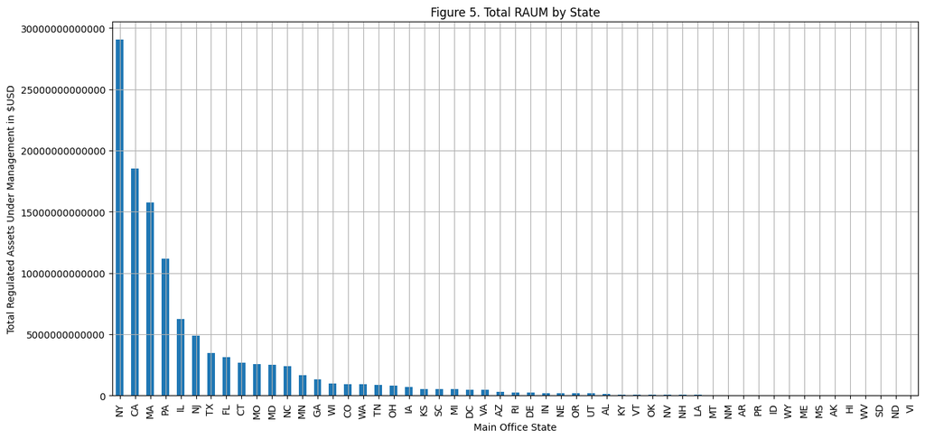

```python
#plot values by state
raum.plot(kind = "bar", title = "Figure 5. Total RAUM by State", grid = True, figsize = (15, 7))
#switch to normal scale from logscale
plt.ticklabel_format(style='plain', axis='y')
#add axis labels
plt.xlabel('Main Office State')
plt.ylabel('Total Regulated Assets Under Management in $USD')
```

##### The chart above highlights the distribution of HNW clients (dollar valued assets) across United States, revealing where wealth is most concentrated. In our previous analysis we saw that MO topped the charts in number of HNW clients served, however, the chart above suggests that even though states like MO cater to large number of millionaires, firms in NY serve a larger dollar value for these fewer but wealthier clients.

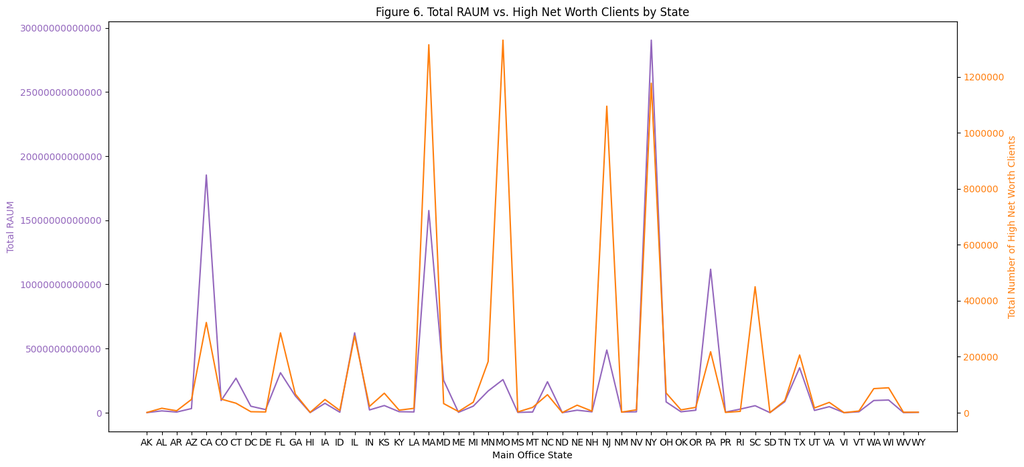

```python
import matplotlib.pyplot as plt
import numpy as np

#calculate necessary values by state
data1 = df_new.groupby("Main Office State").totalraum.sum()
data2 = df_new.groupby('Main Office State')["5D(b)(1)"].sum()

#set formatting parameters
fig, ax1 = plt.subplots(figsize=(15,7))

#select color for line one
color = 'tab:purple'
#set axis labels for line one
ax1.set_xlabel('Main Office State')
ax1.set_ylabel('Total RAUM', color=color)
#select necessary data values to graph
ax1.plot(data1, color=color)
ax1.tick_params(axis='y', labelcolor=color)
plt.ticklabel_format(style='plain', axis='y')

ax2 = ax1.twinx()  # instantiate a second Axes that shares the same x-axis

#select color for line two
color = 'tab:orange'
#set axis labels for line two
ax2.set_ylabel('Total Number of High Net Worth Clients', color=color)
#select necessary data values to graph
ax2.plot(data2, color=color)
ax2.tick_params(axis='y', labelcolor=color)

fig.tight_layout()
#change scale from logscale to normal
plt.ticklabel_format(style='plain', axis='y')
plt.xticks(rotation=45)
plt.title("Figure 6. Total RAUM vs. High Net Worth Clients by State")

plt.show()
```

##### Above the dual axis line chart compares the total Regulatory Assets Under Management (RAUM) and HNW clients across U.S. states. The purple line shows where the most assets are managed with peaks in financial hubs such as NY and CA. The orange line highlights where largest number of HNW clients are served.

```python
from ipywidgets import widgets, interactive, Layout

#make dropdown values to allow user to select the percentage threshold to display
w = widgets.Dropdown(
    options=['All','25%', '50%', '75%', '99%'],
    value = "All",
    description='Percent of High Net Worth Clients',
    disabled=False,
#edit formatting to fit description
    style = {"description_width": '200px'},
    layout = Layout(width="30%")
)

def view(percent):

    #filter by the user selected values
    if percent == "All":
        df_tmp = df_new[df_new['High Net Worth Clients %'] >= 0]
    if percent == "25%":
        df_tmp = df_new[df_new['High Net Worth Clients %'] >= 25]
    if percent == "50%":
        df_tmp = df_new[df_new['High Net Worth Clients %'] >= 50]
    if percent == "75%":
        df_tmp = df_new[df_new['High Net Worth Clients %'] >= 75]
    if percent == "99%":
        df_tmp = df_new[df_new['High Net Worth Clients %'] >= 99]

    #group by state and sum of values
    count = df_tmp.groupby("Main Office State").totalraum.sum()
    count.sort_values(ascending = False)

    #plot bar graph
    count.plot(kind="bar", title="Figure 7. Total RAUM By State with High Net Worth Clients % greater than selected", grid=True, figsize=(15,5))
    plt.ticklabel_format(style='plain', axis='y')
    plt.xlabel('Main Office State')
    plt.ylabel('Total Regulated Assets Under Management in $USD')

#create and display interactive chart
i = interactive(view, percent=w)
display(i)
```

```
interactive(children=(Dropdown(description='Percent of High Net Worth Clients', layout=Layout(width='30%'), op…
```

##### The above interactive visualization shows the number of advisory firm that cater to High Net Worth Clients. By filtering the RAUM by percentage of the assets we can see which states have firms that not only serve wealthy clients but also manage a substantial amount of their assets.

#### Compensation Models of Firms serving High Net Worth Clients

In order to complement our understanding of firm scale and specialization we futher looked into the compensation models offered by different firms.

This section studies the different compensation models. There are 7 total. All of the values in those columns are yes or no answers. Hence the columns first had to be modified in order to combine all of those columns to study the different models. After the columns were combined, the new column needed to be cleaned of extra commas as most of the firms offered more than one compensation model.

```python
import warnings
warnings.filterwarnings("ignore")

##Compensation Models
df_new["5E(1)"]=df_new["5E(1)"].astype(str) ##This column pertains to the "Assets Under Management" model
df_new["5E(2)"]=df_new["5E(2)"].astype(str) ##This column pertains to the "Hourly Charges" model
df_new["5E(3)"]=df_new["5E(3)"].astype(str) ##This column pertains to the "Subscription Fees" model
df_new["5E(4)"]=df_new["5E(4)"].astype(str) ##This column pertains to the "Fixed Fees" model
df_new["5E(5)"]=df_new["5E(5)"].astype(str) ##This column pertains to the "Commissions" model
df_new["5E(6)"]=df_new["5E(6)"].astype(str) ##This column pertains to the "Performance-Based Fees" model
df_new["5E(7)"]=df_new["5E(7)"].astype(str) ##This column pertains to the "Other" model

##Modifying the columns to replace the "Yes" values with the name of the compensation model and the "No" values with blanks
df_new["5E(1)"].replace(["Y", "N"],["Assets_Under_Management", ""], inplace=True)
df_new["5E(2)"].replace(["Y", "N"],["Hourly_Charges",""], inplace=True)
df_new["5E(3)"].replace(["Y", "N"],["Subscription_Fees", ""], inplace=True)
df_new["5E(4)"].replace(["Y", "N"],["Fixed_Fees", ""], inplace=True)
df_new["5E(5)"].replace(["Y", "N"],["Commissions",""], inplace=True)
df_new["5E(6)"].replace(["Y", "N"],["Performance_Based_Fees",""], inplace=True)
df_new["5E(7)"].replace(["Y", "N"],["Other",""], inplace=True)

##Combine columns "5E(1)" to "5E(7)" into one column using concatenation. The new column name is "pay type"
df_new["pay type"]=df_new["5E(1)"]+","+df_new["5E(2)"]+","+df_new["5E(3)"]+","+df_new["5E(4)"]+","+df_new["5E(5)"]+","+df_new["5E(6)"]+","+df_new["5E(7)"]

##Remove extra commas from the new column. In the process, create a new column called "compensation"
df_new["compensation"]=df_new["pay type"].apply(lambda x: x.rstrip(",").lstrip(",").replace(",,",",").replace(",,",",").replace(",,",","))
##df_new["compensation"]=df_new["compensation"].astype(str)
df_new["compensation"]
```

```
0        Assets_Under_Management,Hourly_Charges,Fixed_F...
1           Assets_Under_Management,Fixed_Fees,Commissions
2                            Assets_Under_Management,Other
3        Assets_Under_Management,Hourly_Charges,Fixed_Fees
4                                  Assets_Under_Management
                               ...
15956       Assets_Under_Management,Performance_Based_Fees
15957                        Assets_Under_Management,Other
15959                                                Other
15961       Assets_Under_Management,Performance_Based_Fees
15962       Assets_Under_Management,Performance_Based_Fees
Name: compensation, Length: 13969, dtype: object
```

The cell below is to separate each individual compensation type in order to get a total count of the number of firms that were compensated through each model. As you can see above, each cell is comma separated so we wanted to categorize them into individual components. "Compensation_Type" is the new column we are using in our analysis.

```python
##The new columns "pay type" and "compensation", that were created in the cell above, combined the 7 columns pertaining to the different compensation models. That resulted in each value in those columns having a bunch of comma separated values
##One of the goals for this project was to analyze each model individually so that's what this cell does. In the process, a new column called "Compensation_Type" was created
df_new["Compensation_Type"]=df_new["compensation"].astype(str)
df_new["Compensation_Type"]=df_new["compensation"].str.split(",")
df_new2=df_new.explode("Compensation_Type") ##Used the "explode" function to separate each model into individual categories
df_new2
```

|  | SEC Region | Organization CRD# | Additional CRD Number | Total number of additional CRD numbers | SEC# | Firm Type | Umbrella Registration | Total number of relying advisers | CIK# | Total number of CIK numbers | ... | 12B(1) | 12B(2) | 12C(1) | 12C(2) | temp1 | HNWC | High Net Worth Clients % | pay type | compensation | Compensation_Type |
| --- | --- | --- | --- | --- | --- | --- | --- | --- | --- | --- | --- | --- | --- | --- | --- | --- | --- | --- | --- | --- | --- |
| 0 | SFRO | 38 | NaN | NaN | 801-57838 | Registered | N | NaN | NaN | NaN | ... | NaN | NaN | NaN | NaN | 1 | 221 | 68.11 | Assets_Under_Management,Hourly_Charges,,Fixed_... | Assets_Under_Management,Hourly_Charges,Fixed_F... | Assets_Under_Management |
| 0 | SFRO | 38 | NaN | NaN | 801-57838 | Registered | N | NaN | NaN | NaN | ... | NaN | NaN | NaN | NaN | 1 | 221 | 68.11 | Assets_Under_Management,Hourly_Charges,,Fixed_... | Assets_Under_Management,Hourly_Charges,Fixed_F... | Hourly_Charges |
| 0 | SFRO | 38 | NaN | NaN | 801-57838 | Registered | N | NaN | NaN | NaN | ... | NaN | NaN | NaN | NaN | 1 | 221 | 68.11 | Assets_Under_Management,Hourly_Charges,,Fixed_... | Assets_Under_Management,Hourly_Charges,Fixed_F... | Fixed_Fees |
| 0 | SFRO | 38 | NaN | NaN | 801-57838 | Registered | N | NaN | NaN | NaN | ... | NaN | NaN | NaN | NaN | 1 | 221 | 68.11 | Assets_Under_Management,Hourly_Charges,,Fixed_... | Assets_Under_Management,Hourly_Charges,Fixed_F... | Commissions |
| 1 | NYRO | 70 | NaN | NaN | 801-56943 | Registered | N | NaN | 9319.0 | 1.0 | ... | NaN | NaN | NaN | NaN | 1 | 114 | 33.00 | Assets_Under_Management,,,Fixed_Fees,Commissio... | Assets_Under_Management,Fixed_Fees,Commissions | Assets_Under_Management |
| ... | ... | ... | ... | ... | ... | ... | ... | ... | ... | ... | ... | ... | ... | ... | ... | ... | ... | ... | ... | ... | ... |
| 15959 | NYRO | 322260 | NaN | NaN | 801-126110 | Registered | N | NaN | NaN | NaN | ... | NaN | NaN | NaN | NaN | 1 | 0 | 0.00 | ,,,,,,Other | Other | Other |
| 15961 | NYRO | 163597 | NaN | NaN | 801-77719 | Registered | N | NaN | 1566691.0 | 1.0 | ... | NaN | NaN | NaN | NaN | 1 | 0 | 0.00 | Assets_Under_Management,,,,,Performance_Based_... | Assets_Under_Management,Performance_Based_Fees | Assets_Under_Management |
| 15961 | NYRO | 163597 | NaN | NaN | 801-77719 | Registered | N | NaN | 1566691.0 | 1.0 | ... | NaN | NaN | NaN | NaN | 1 | 0 | 0.00 | Assets_Under_Management,,,,,Performance_Based_... | Assets_Under_Management,Performance_Based_Fees | Performance_Based_Fees |
| 15962 | LARO | 328574 | NaN | NaN | 801-129101 | Registered | N | NaN | NaN | NaN | ... | NaN | NaN | NaN | NaN | 1 | 0 | 0.00 | Assets_Under_Management,,,,,Performance_Based_... | Assets_Under_Management,Performance_Based_Fees | Assets_Under_Management |
| 15962 | LARO | 328574 | NaN | NaN | 801-129101 | Registered | N | NaN | NaN | NaN | ... | NaN | NaN | NaN | NaN | 1 | 0 | 0.00 | Assets_Under_Management,,,,,Performance_Based_... | Assets_Under_Management,Performance_Based_Fees | Performance_Based_Fees |

31605 rows × 467 columns

```python
##Column "5D(b)(1)" corresponds to the number of high net worth clients
df_new2["5D(b)(1)"]=df_new2["5D(b)(1)"].apply(lambda x: int(x)) ##Convert the values for high net worth clients to an integer
df_new2[["SEC Region", "SEC#", "5D(b)(1)", "compensation", "Compensation_Type"]] ##checking to make sure that using the new dataframe df_new2 doesn't skew the data in bar chart by adding the number of high networth clients for each firm 3 or 4 times
```

|  | SEC Region | SEC# | 5D(b)(1) | compensation | Compensation_Type |
| --- | --- | --- | --- | --- | --- |
| 0 | SFRO | 801-57838 | 221 | Assets_Under_Management,Hourly_Charges,Fixed_F... | Assets_Under_Management |
| 0 | SFRO | 801-57838 | 221 | Assets_Under_Management,Hourly_Charges,Fixed_F... | Hourly_Charges |
| 0 | SFRO | 801-57838 | 221 | Assets_Under_Management,Hourly_Charges,Fixed_F... | Fixed_Fees |
| 0 | SFRO | 801-57838 | 221 | Assets_Under_Management,Hourly_Charges,Fixed_F... | Commissions |
| 1 | NYRO | 801-56943 | 114 | Assets_Under_Management,Fixed_Fees,Commissions | Assets_Under_Management |
| ... | ... | ... | ... | ... | ... |
| 15959 | NYRO | 801-126110 | 0 | Other | Other |
| 15961 | NYRO | 801-77719 | 0 | Assets_Under_Management,Performance_Based_Fees | Assets_Under_Management |
| 15961 | NYRO | 801-77719 | 0 | Assets_Under_Management,Performance_Based_Fees | Performance_Based_Fees |
| 15962 | LARO | 801-129101 | 0 | Assets_Under_Management,Performance_Based_Fees | Assets_Under_Management |
| 15962 | LARO | 801-129101 | 0 | Assets_Under_Management,Performance_Based_Fees | Performance_Based_Fees |

31605 rows × 5 columns

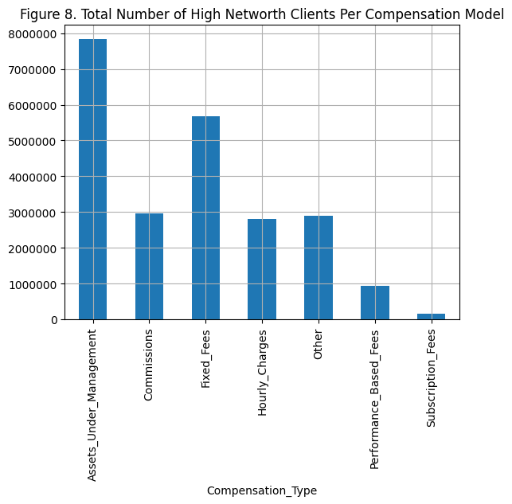

```python
##As stated in the cell above, column "5D(b)(1)" corresponds to the number of high net worth clients for each firm

##Replace all null values in column "5D(b)(1) with "0"
df_new["5D(b)(1)"]=df_new["5D(b)(1)"].fillna(value=0)

##Get the numbers in column "5D(b)(1)" as an integer value. Decided to create a new column "HNWC" which stands for "High Net Worth Clients". Again, we want the values in that column to be an integer
df_new2["HNWC"]=df_new["5D(b)(1)"].apply(lambda x: int(x))

##Get the total number of high networth clients for each compensation model.
count2=df_new2.groupby("Compensation_Type").HNWC.sum()
count2.plot(kind="bar", title="Figure 8. Total Number of High Networth Clients Per Compensation Model", grid=True)

#Using plain formatting vs.scientific notation
plt.ticklabel_format(style='plain', axis='y')
```

#### The chart above shows the "Asset Under Management" (AUM) fee model was mostly used for High Net Worth Clients, followed by Fixed Fees and Commission. But it is important to note numbers for AUM was considerably more. This suggests that wealthier clients might prefer advisors whose incentives are more aligned with asset growth.

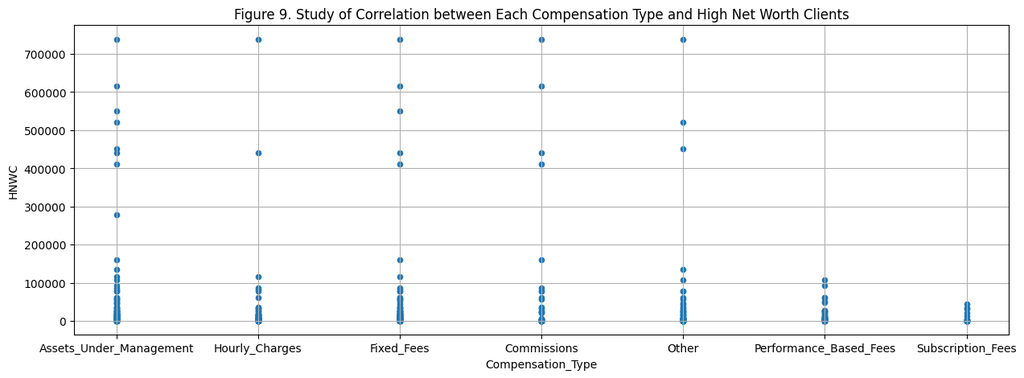

```python
##See if there is a correlation between compensation models and the number of high net worth clients
df_new2.plot(kind="scatter", title="Figure 9. Study of Correlation between Each Compensation Type and High Net Worth Clients", x="Compensation_Type", y="HNWC", grid=True, figsize=(15,5))
```

In addition to the above visualizations, we also explored what compensation model was most popular among the firms. The interactive model shows the number of firms compensated through each of the seven models.

```python
##Rename column "SEC#" to use for count function in groupby
##Each firm is referenced through their SEC#
df_new2=df_new2.rename(columns={"SEC#": "SEC_Num"})

type_compensation=widgets.RadioButtons(
    options=["All", "Assets_Under_Management", "Commissions", "Fixed_Fees", "Hourly_Charges", "Other", "Performance_Based_Fees", "Subscription_Fees"],
     value="All",
    description="Compensation Model:",
    disabled=False
)

def view(model):
    if model=="All":
        df_tmp2=df_new2
    else:
        df_tmp2=df_new2[df_new2.Compensation_Type==model]

    title="Figure 10: Number of firms compensated through: {}".format(model)

    count3=df_tmp2.groupby("Compensation_Type").SEC_Num.count()
    count3.plot(kind="barh", title=title, grid=True, figsize=(10,10))


i=interactive(view,model=type_compensation)
display(i)
```

```
interactive(children=(RadioButtons(description='Compensation Model:', options=('All', 'Assets_Under_Management…
```

##### The above visualization shows the no. of firms using each compensation model. It turns out that AUM compensation model is not only most preferred among HNW clients but also the most widely used compensation model across all firms.

## Machine Learning

In order to better understand what a typical firm looks like, we calculated average values for key attributes like RAUM, percentage of HNW Clients and employee count. These averages served as a baseline for modeling and comparing different firm profiles.

```python
#calc averages to use as default values
AvgHNWC=df_new["High Net Worth Clients %"].mean()
AVGtotalraum=df_new["totalraum"].mean()
AVGempcount=df_new["5A"].mean()

#print averages
print("Average High Net Worth Clients %={}".format(AvgHNWC),end="\n")
print("Average RAUM={}".format(AVGtotalraum),end="\n")
print("Average Employee Count={}".format(AVGempcount),end="\n")
```

```
Average High Net Worth Clients %=36.42191280692963
Average RAUM=8292606074.154628
Average Employee Count=65.8391323024055
```

```python
# Load only the specific columns from the CSV. Replace data that had been changed in the previous analysis with orginal data.
new_columns = pd.read_csv("ia020325.csv", usecols=["5E(1)"], low_memory=False)
df_new = df_new.drop(columns=["5E(1)"])
df_new = df_new.join(new_columns)

new_columns = pd.read_csv("ia020325.csv", usecols=["5E(2)"], low_memory=False)
df_new = df_new.drop(columns=["5E(2)"])
df_new = df_new.join(new_columns)

new_columns = pd.read_csv("ia020325.csv", usecols=["5E(3)"], low_memory=False)
df_new = df_new.drop(columns=["5E(3)"])
df_new = df_new.join(new_columns)

new_columns = pd.read_csv("ia020325.csv", usecols=["5E(4)"], low_memory=False)
df_new = df_new.drop(columns=["5E(4)"])
df_new = df_new.join(new_columns)

new_columns = pd.read_csv("ia020325.csv", usecols=["5E(5)"], low_memory=False)
df_new = df_new.drop(columns=["5E(5)"])
df_new = df_new.join(new_columns)

new_columns = pd.read_csv("ia020325.csv", usecols=["5E(6)"], low_memory=False)
df_new = df_new.drop(columns=["5E(6)"])
df_new = df_new.join(new_columns)

new_columns = pd.read_csv("ia020325.csv", usecols=["5E(7)"], low_memory=False)
df_new = df_new.drop(columns=["5E(7)"])
df_new = df_new.join(new_columns)

#convert training data to usable format
df_new["5E(1)"]=df_new["5E(1)"].apply(lambda x: 1 if x == "Y" else 0 )
df_new["5E(2)"]=df_new["5E(2)"].apply(lambda x: 1 if x == "Y" else 0 )
df_new["5E(3)"]=df_new["5E(3)"].apply(lambda x: 1 if x == "Y" else 0 )
df_new["5E(4)"]=df_new["5E(4)"].apply(lambda x: 1 if x == "Y" else 0 )
df_new["5E(5)"]=df_new["5E(5)"].apply(lambda x: 1 if x == "Y" else 0 )
df_new["5E(6)"]=df_new["5E(6)"].apply(lambda x: 1 if x == "Y" else 0 )
df_new["5E(7)"]=df_new["5E(7)"].apply(lambda x: 1 if x == "Y" else 0 )
df_new["5A"] = df_new["5A"].fillna(value=0)

# Dictionary mapping state abbreviations to numerical values
state_to_number = {
    'AL': 1, 'AK': 2, 'AZ': 3, 'AR': 4, 'CA': 5, 'CO': 6, 'CT': 7, 'DE': 8,
    'DC': 9, 'FL': 10, 'GA': 11, 'HI': 12, 'ID': 13, 'IL': 14, 'IN': 15,
    'IA': 16, 'KS': 17, 'KY': 18, 'LA': 19, 'ME': 20, 'MD': 21, 'MA': 22,
    'MI': 23, 'MN': 24, 'MS': 25, 'MO': 26, 'MT': 27, 'NE': 28, 'NV': 29,
    'NH': 30, 'NJ': 31, 'NM': 32, 'NY': 33, 'NC': 34, 'ND': 35, 'OH': 36,
    'OK': 37, 'OR': 38, 'PA': 39, 'RI': 40, 'SC': 41, 'SD': 42, 'TN': 43,
    'TX': 44, 'UT': 45, 'VT': 46, 'VA': 47, 'WA': 48, 'WV': 49, 'WI': 50,
    'WY': 51,'PR': 52,'VI': 53
}

#create new column mapping state abbreviation to number
df_new['State_Number'] = df_new['Main Office State'].map(state_to_number)

df_new[["State_Number","Main Office State"]]

#create training data
features = ["High Net Worth Clients %","totalraum","5E(1)","5E(2)","5E(3)","5E(4)","5E(5)","5E(6)","5E(7)","5A"]
target = "State_Number"
X = df_new[features]
y = df_new[target]


#import train_test_split & KNeighborsClassifier
from sklearn.model_selection import train_test_split
from sklearn.neighbors import KNeighborsClassifier

#split training and test data
X_train, X_test, y_train, y_test = train_test_split(X, y, test_size=.25, random_state=0)

#pick and set model
knc = KNeighborsClassifier(n_neighbors=1)

#train model
knc.fit(X_train, y_train)

# set description width so it is not cut off
style = {'description_width': 'initial'}


#configure sliders and checkboxs for the user to change
RAUM = widgets.IntSlider(
    value=AVGtotalraum,
    min=0,
    max=3500000000000,
    step=1000000,
    description='RAUM:',
    style=style,
    disabled=False,
    continuous_update=False,
    orientation='horizontal',
    readout=True,
    readout_format='$d',
    layout = widgets.Layout(width='500px')
)

HNWC = widgets.IntSlider(
    value=AvgHNWC,
    min=0,
    max=100,
    step=1,
    description='High Net Worth Clients %:',
    style=style,
    disabled=False,
    continuous_update=False,
    orientation='horizontal',
    readout=True,
    readout_format='d',
    layout = widgets.Layout(width='500px')
)

number_emp = widgets.IntSlider(
    value=AVGempcount,
    min=0,
    max=35000,
    step=100,
    description='Total number of firm employees:',
    style=style,
    disabled=False,
    continuous_update=False,
    orientation='horizontal',
    readout=True,
    readout_format='d',
    layout = widgets.Layout(width='500px')
)


comp1 = widgets.Checkbox(
    value=True,
    description='A percentage of assets under your management',
    style=style,
    disabled=False,
    indent=False
)

comp2 = widgets.Checkbox(
    value=True,
    description='Hourly charges',
    style=style,
    disabled=False,
    indent=False
)

comp3 = widgets.Checkbox(
    value=True,
    description='Subscription fees (for a newsletter or periodical)',
    style=style,
    disabled=False,
    indent=False
)

comp4 = widgets.Checkbox(
    value=True,
    description='Fixed fees (other than subscription fees)',
    style=style,
    disabled=False,
    indent=False
)

comp5 = widgets.Checkbox(
    value=True,
    description='Commissions',
    style=style,
    disabled=False,
    indent=False
)

comp6 = widgets.Checkbox(
    value=True,
    description='Performance-based fees',
    style=style,
    disabled=False,
    indent=False
)

comp7 = widgets.Checkbox(
    value=True,
    description='Other',
    style=style,
    disabled=False,
    indent=False
)

def view(RAUM,HNWC,number_emp,comp1,comp2,comp3,comp4,comp5,comp6,comp7):


    #convert checkbox value to 1 or 0
    if comp1==True:
        comp1=1
    else:
        comp1=0

    #convert checkbox value to 1 or 0
    if comp2==True:
        comp2=1
    else:
        comp2=0

    #convert checkbox value to 1 or 0
    if comp3==True:
        comp3=1
    else:
        comp3=0

    #convert checkbox value to 1 or 0
    if comp4==True:
        comp4=1
    else:
        comp4=0

    #convert checkbox value to 1 or 0
    if comp5==True:
        comp5=1
    else:
        comp5=0

    #convert checkbox value to 1 or 0
    if comp6==True:
        comp6=1
    else:
        comp6=0

    #convert checkbox value to 1 or 0
    if comp7==True:
        comp7=1
    else:
        comp7=0


    #create dicticonary of user input
    new_input = {"High Net Worth Clients %": HNWC,
           "totalraum": RAUM,
           "5E(1)": comp1,
           "5E(2)": comp2,
           "5E(3)": comp3,
           "5E(4)": comp4,
           "5E(5)": comp5,
           "5E(6)": comp6,
           "5E(7)": comp7,
           "5A": number_emp}

    #load user input into dataframe
    X_new = []
    X_new.append(new_input)
    X_new = pd.DataFrame(data=X_new, columns=features)

    #Predict state using user input
    predictedstate=knc.predict(X_new)

    #Convert state number back into 2 char format and print to screen
    print("The best state to have your home office in with the above parameters is {}.".format(convert_state_from_number(predictedstate)),end=" ")

def convert_state_from_number(predicted_state):
    #Converts a state number back into its 2-character abbreviation format and returns it.
    for state, statenumber in state_to_number.items():
        if statenumber == predicted_state:
            return state
            break



#make interactive and pass nessary user input data
i = interactive(view, RAUM=RAUM,HNWC=HNWC,number_emp=number_emp,comp1=comp1,comp2=comp2,comp3=comp3,comp4=comp4,comp5=comp5,comp6=comp6,comp7=comp7)
display(i)
```

```
interactive(children=(IntSlider(value=8292606074, continuous_update=False, description='RAUM:', layout=Layout(…
```

### Conclusion

#### Main Question: What defines the successful investment advisor for High Net Worth clients?

#### Sub-questions:

##### 1. Where should they be located?

##### 2. What level of AUM should they target?

##### 3. How should they structure their fees?

Interactive tools in the analysis allowed us to explore how firm attributes such as RAUM, employee size and compensation model influence the best location to have an office. To summarize, the data findings indicate that a successful investment advisor for HNW client is shaped by a balanced mix of scale, specialization and compensation structure and not just location alone.

### Video Presentation

https://iowa-my.sharepoint.com/:v:/g/personal/timjacobs_uiowa_edu/EavjB9uQGnRBqdJdwWVtUaEBXTTAN1Barm7SEtvwwyOdeg?e=aFaIso